# Influencia de la depreciación sobre la inflación en Colombia

[Gustavo A. García](https://gusgarciacruz.github.io/cv)

[Econometría 2](https://gusgarciacruz.github.io/EconometriaII) - Universidad EAFIT

2023-03

- **inflación de Colombia**: variación porcentual del IPC de un mes con respecto al IPC del mismo mes del año anterior (fuente: [DANE](https://www.dane.gov.co/files/investigaciones/ipc/ene23/IPC_Indices.xlsx))
- **depreciación**: variación porcentual de la tasa representativa del mercado (TRM) de un mes con respecto a la TRM del mismo mes del año anterior (fuente: [Banco de la República](https://www.banrep.gov.co/es/estadisticas/trm))
- **inflación de los Estados Unidos**: variación porcentual del IPC de un mes con respecto al IPC del mismo mes del año anterior (fuente: [Federal Reserve Bank of St. Louis](https://fred.stlouisfed.org/series/CPIAUCSL))

Las variables endógenas son la inflación para Colombia y la depreciación, mientras como variable exógena se tiene la inflación de Estados Unidos.

## Análisis gráfico

A continuación cargamos los datos y realizamos los gráficos de las series

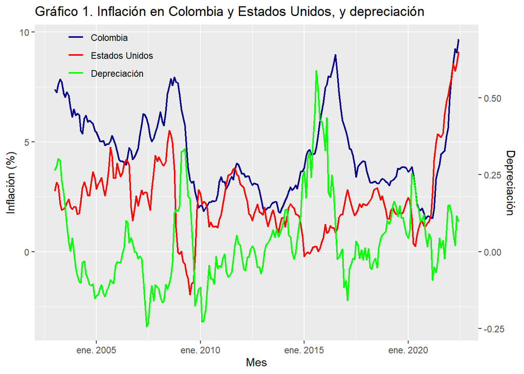

```r
library(fpp3); library(tidyverse); library(vars); library(urca); library(forecast)
library(openxlsx)
data <- read.xlsx("https://gusgarciacruz.github.io/EconometriaII/IntroVar/Inflacion_depreciacion_enero2003_junio2022.xlsx") |>
  mutate(date = as.yearmon(date))

ggplot(data) +
  geom_line(aes(x = date, y = infcol, colour = "Colombia"), size = 0.8) +
  geom_line(aes(x = date, y = Infeeuu, colour = "Estados Unidos"), size = 0.8) +
  geom_line(aes(x = date, y = Dep*14, colour = "Depreciación"), size = 0.8) +
  scale_colour_manual(name = "", values = c("Colombia" = "darkblue", "Estados Unidos" = "red", "Depreciación" = "green"), limits = c("Colombia", "Estados Unidos", "Depreciación")) +
  labs(title = "Gráfico 1. Inflación en Colombia y Estados Unidos, y depreciación", x = "Mes", y ="") +
  theme(legend.position = c(0.17, 0.93),
        legend.background = element_rect(fill="transparent", colour ="transparent"),
        legend.key = element_rect(fill = "transparent", colour = "transparent")) +
  scale_y_continuous(name = "Inflación (%)",
                     sec.axis = sec_axis(~./14, name="Depreciación"))
```

## Pruebas de estacionariedad

Ahora pasamos a determinar si las series son o no estacionarias y para ello calculamos los correlogramas y las pruebas de raices unitarias

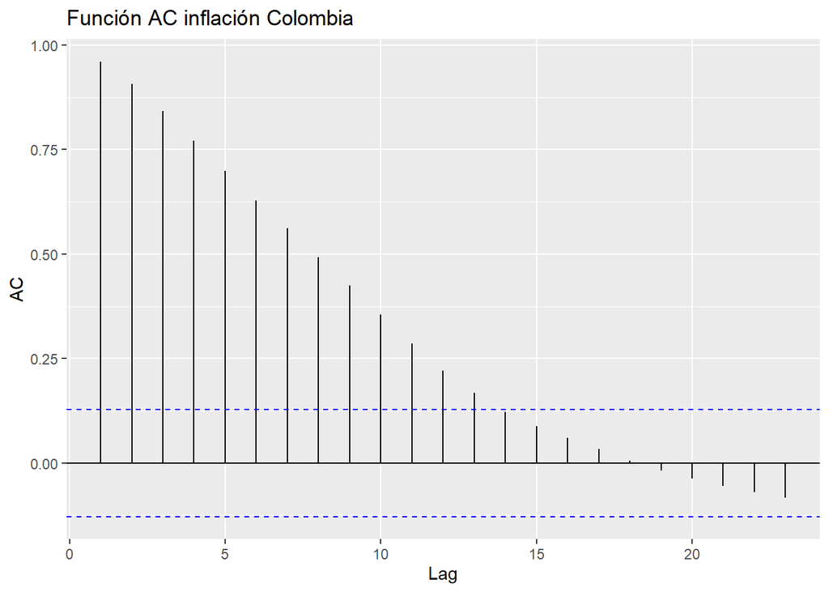

```r
ggAcf(data$infcol, main="Función AC inflación Colombia",
      ylab="AC")
```

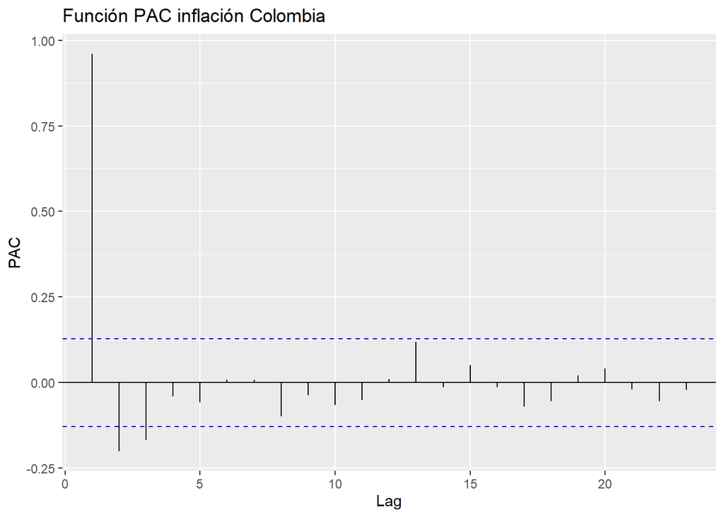

```r
ggPacf(data$infcol, main="Función PAC inflación Colombia",
       ylab="PAC")
```

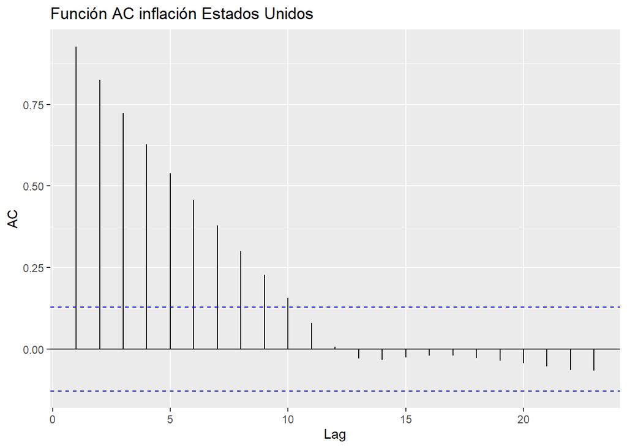

```r
ggAcf(data$Infeeuu,
      main="Función AC inflación Estados Unidos",
      ylab="AC")
```

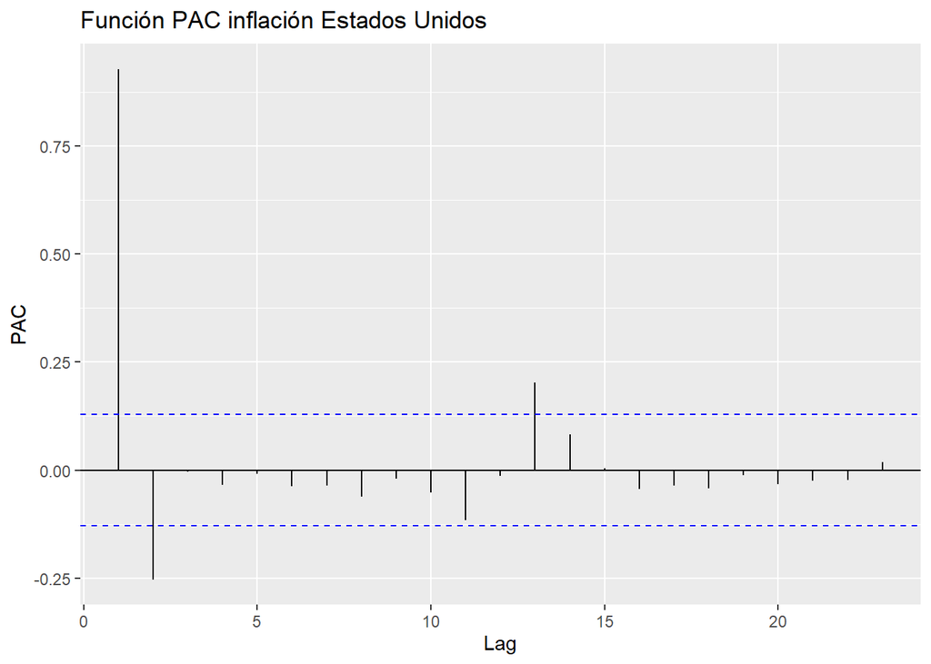

```r
ggPacf(data$Infeeuu,
       main="Función PAC inflación Estados Unidos",
       ylab="PAC")
```

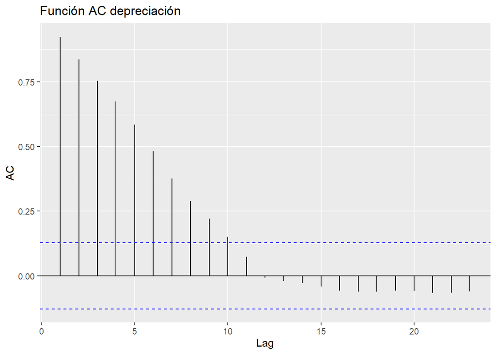

```r
ggAcf(data$Dep, main="Función AC depreciación",
      ylab="AC")
```

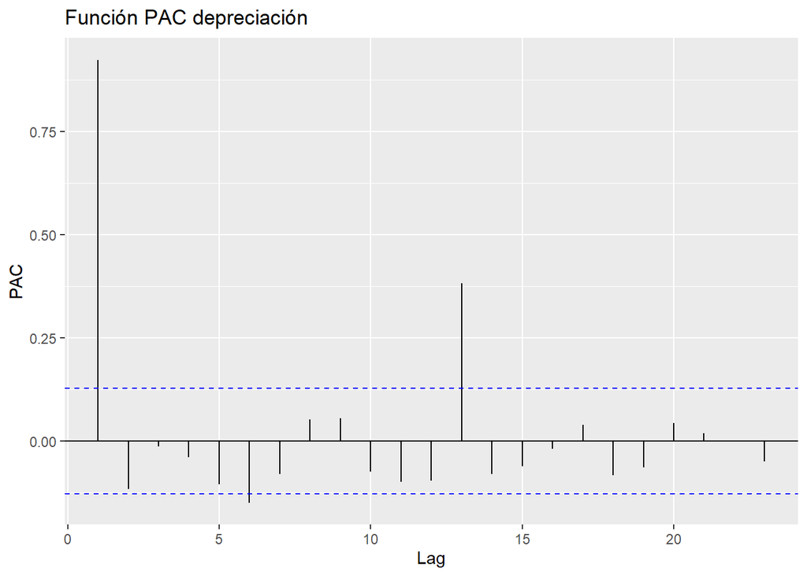

```r
ggPacf(data$Dep, main="Función PAC depreciación",
       ylab="PAC")
```

```r
DF_infcol <- ur.df(data$infcol, type="trend",
                   selectlags = "AIC")
summary(DF_infcol)
```

```
##
## ###############################################
## # Augmented Dickey-Fuller Test Unit Root Test #
## ###############################################
##
## Test regression trend
##
##
## Call:
## lm(formula = z.diff ~ z.lag.1 + 1 + tt + z.diff.lag)
##
## Residuals:
##      Min       1Q   Median       3Q      Max
## -1.01529 -0.19441 -0.02086  0.15108  1.10567
##
## Coefficients:
##               Estimate Std. Error t value Pr(>|t|)
## (Intercept)  0.0420082  0.0740164   0.568    0.571
## z.lag.1     -0.0162162  0.0113646  -1.427    0.155
## tt           0.0003089  0.0003133   0.986    0.325
## z.diff.lag   0.5362034  0.0578482   9.269   <2e-16 ***
## ---
## Signif. codes:  0 '***' 0.001 '**' 0.01 '*' 0.05 '.' 0.1 ' ' 1
##
## Residual standard error: 0.2971 on 228 degrees of freedom
## Multiple R-squared:  0.2955, Adjusted R-squared:  0.2863
## F-statistic: 31.88 on 3 and 228 DF,  p-value: < 2.2e-16
##
##
## Value of test-statistic is: -1.4269 1.5218 2.2241
##
## Critical values for test statistics:
##       1pct  5pct 10pct
## tau3 -3.99 -3.43 -3.13
## phi2  6.22  4.75  4.07
## phi3  8.43  6.49  5.47
```

```r
DF_infeeuu <- ur.df(data$Infeeuu, type="trend",
                    selectlags = "AIC")
summary(DF_infeeuu)
```

```
##
## ###############################################
## # Augmented Dickey-Fuller Test Unit Root Test #
## ###############################################
##
## Test regression trend
##
##
## Call:
## lm(formula = z.diff ~ z.lag.1 + 1 + tt + z.diff.lag)
##
## Residuals:
##      Min       1Q   Median       3Q      Max
## -1.96687 -0.23152  0.01454  0.22984  1.47638
##
## Coefficients:
##               Estimate Std. Error t value Pr(>|t|)
## (Intercept)  0.0491637  0.0684954   0.718   0.4736
## z.lag.1     -0.0412450  0.0172245  -2.395   0.0174 *
## tt           0.0005097  0.0004149   1.229   0.2205
## z.diff.lag   0.4869905  0.0602511   8.083  3.7e-14 ***
## ---
## Signif. codes:  0 '***' 0.001 '**' 0.01 '*' 0.05 '.' 0.1 ' ' 1
##
## Residual standard error: 0.4209 on 228 degrees of freedom
## Multiple R-squared:  0.2341, Adjusted R-squared:  0.2241
## F-statistic: 23.23 on 3 and 228 DF,  p-value: 3.688e-13
##
##
## Value of test-statistic is: -2.3945 2.505 3.6245
##
## Critical values for test statistics:
##       1pct  5pct 10pct
## tau3 -3.99 -3.43 -3.13
## phi2  6.22  4.75  4.07
## phi3  8.43  6.49  5.47
```

```r
DF_dep <- ur.df(data$Dep, type="trend", selectlags = "AIC")
summary(DF_dep)
```

```
##
## ###############################################
## # Augmented Dickey-Fuller Test Unit Root Test #
## ###############################################
##
## Test regression trend
##
##
## Call:
## lm(formula = z.diff ~ z.lag.1 + 1 + tt + z.diff.lag)
##
## Residuals:
##       Min        1Q    Median        3Q       Max
## -0.217472 -0.028904  0.000466  0.022666  0.192602
##
## Coefficients:
##               Estimate Std. Error t value Pr(>|t|)
## (Intercept) -8.761e-03  7.026e-03  -1.247 0.213701
## z.lag.1     -9.750e-02  2.561e-02  -3.807 0.000181 ***
## tt           9.415e-05  5.380e-05   1.750 0.081432 .
## z.diff.lag   1.138e-01  6.500e-02   1.751 0.081338 .
## ---
## Signif. codes:  0 '***' 0.001 '**' 0.01 '*' 0.05 '.' 0.1 ' ' 1
##
## Residual standard error: 0.05228 on 228 degrees of freedom
## Multiple R-squared:  0.06642,    Adjusted R-squared:  0.05414
## F-statistic: 5.407 on 3 and 228 DF,  p-value: 0.001304
##
##
## Value of test-statistic is: -3.8072 4.9807 7.4484
##
## Critical values for test statistics:
##       1pct  5pct 10pct
## tau3 -3.99 -3.43 -3.13
## phi2  6.22  4.75  4.07
## phi3  8.43  6.49  5.47
```

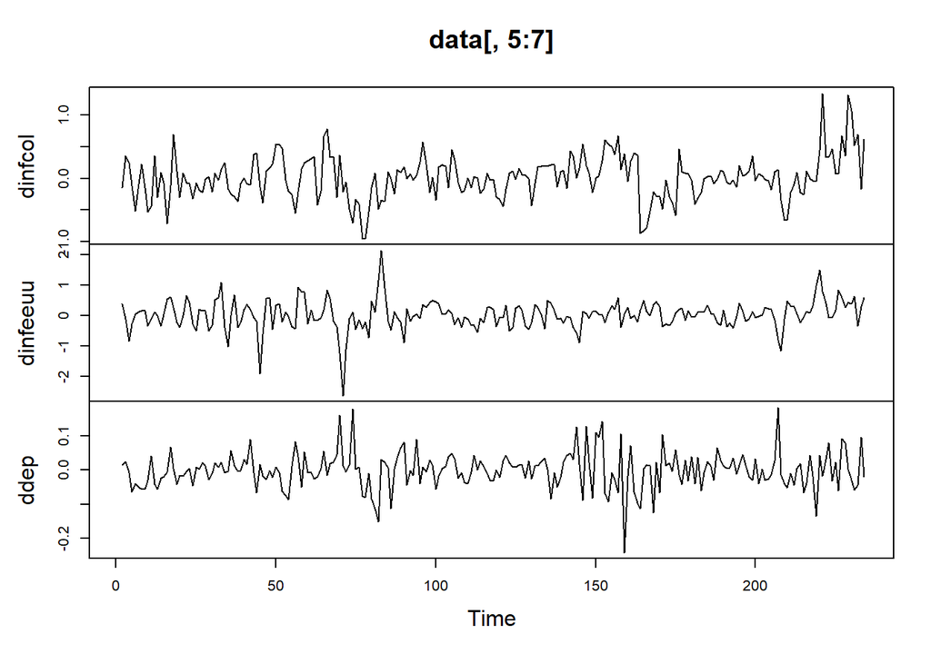

```r
data <- data |>
  mutate(dinfcol = c(NA,diff(infcol,1)),
         dinfeeuu = c(NA,diff(Infeeuu,1)),
         ddep = c(NA,diff(Dep,1)))
plot.ts(data[,5:7])
```

Realizamos pruebas de raices unitarias a las series diferenciadas para chequear que ya sean estacionarias

```r
DF_dinfcol <- ur.df(na.omit(data$dinfcol), type="trend",
                   selectlags = "AIC")
summary(DF_dinfcol)
```

```
##
## ###############################################
## # Augmented Dickey-Fuller Test Unit Root Test #
## ###############################################
##
## Test regression trend
##
##
## Call:
## lm(formula = z.diff ~ z.lag.1 + 1 + tt + z.diff.lag)
##
## Residuals:
##      Min       1Q   Median       3Q      Max
## -1.09106 -0.19032 -0.00871  0.16202  1.07029
##
## Coefficients:
##               Estimate Std. Error t value Pr(>|t|)
## (Intercept) -0.0549276  0.0399652  -1.374   0.1707
## z.lag.1     -0.4781410  0.0649994  -7.356 3.43e-12 ***
## tt           0.0005113  0.0002987   1.712   0.0883 .
## z.diff.lag  -0.0022002  0.0667830  -0.033   0.9737
## ---
## Signif. codes:  0 '***' 0.001 '**' 0.01 '*' 0.05 '.' 0.1 ' ' 1
##
## Residual standard error: 0.2973 on 227 degrees of freedom
## Multiple R-squared:  0.2395, Adjusted R-squared:  0.2294
## F-statistic: 23.83 on 3 and 227 DF,  p-value: 1.92e-13
##
##
## Value of test-statistic is: -7.3561 18.0765 27.1132
##
## Critical values for test statistics:
##       1pct  5pct 10pct
## tau3 -3.99 -3.43 -3.13
## phi2  6.22  4.75  4.07
## phi3  8.43  6.49  5.47
```

```r
DF_dinfeeuu <- ur.df(na.omit(data$dinfeeuu), type="trend",
                    selectlags = "AIC")
summary(DF_dinfeeuu)
```

```
##
## ###############################################
## # Augmented Dickey-Fuller Test Unit Root Test #
## ###############################################
##
## Test regression trend
##
##
## Call:
## lm(formula = z.diff ~ z.lag.1 + 1 + tt + z.diff.lag)
##
## Residuals:
##      Min       1Q   Median       3Q      Max
## -2.01980 -0.21012  0.01721  0.20129  1.51427
##
## Coefficients:
##               Estimate Std. Error t value Pr(>|t|)
## (Intercept) -0.0477356  0.0551258  -0.866 0.387438
## z.lag.1     -0.6819312  0.0674218 -10.114  < 2e-16 ***
## tt           0.0005704  0.0004112   1.387 0.166755
## z.diff.lag   0.2468993  0.0642710   3.842 0.000159 ***
## ---
## Signif. codes:  0 '***' 0.001 '**' 0.01 '*' 0.05 '.' 0.1 ' ' 1
##
## Residual standard error: 0.4135 on 227 degrees of freedom
## Multiple R-squared:  0.3167, Adjusted R-squared:  0.3076
## F-statistic: 35.07 on 3 and 227 DF,  p-value: < 2.2e-16
##
##
## Value of test-statistic is: -10.1144 34.11 51.159
##
## Critical values for test statistics:
##       1pct  5pct 10pct
## tau3 -3.99 -3.43 -3.13
## phi2  6.22  4.75  4.07
## phi3  8.43  6.49  5.47
```

```r
DF_ddep <- ur.df(na.omit(data$ddep), type="trend", selectlags = "AIC")
summary(DF_ddep)
```

```
##
## ###############################################
## # Augmented Dickey-Fuller Test Unit Root Test #
## ###############################################
##
## Test regression trend
##
##
## Call:
## lm(formula = z.diff ~ z.lag.1 + 1 + tt + z.diff.lag)
##
## Residuals:
##       Min        1Q    Median        3Q       Max
## -0.252610 -0.029848  0.003841  0.025277  0.179392
##
## Coefficients:
##               Estimate Std. Error t value Pr(>|t|)
## (Intercept) -5.144e-03  7.183e-03  -0.716    0.475
## z.lag.1     -9.637e-01  9.048e-02 -10.651   <2e-16 ***
## tt           3.649e-05  5.333e-05   0.684    0.494
## z.diff.lag   3.758e-02  6.675e-02   0.563    0.574
## ---
## Signif. codes:  0 '***' 0.001 '**' 0.01 '*' 0.05 '.' 0.1 ' ' 1
##
## Residual standard error: 0.05397 on 227 degrees of freedom
## Multiple R-squared:  0.4654, Adjusted R-squared:  0.4583
## F-statistic: 65.86 on 3 and 227 DF,  p-value: < 2.2e-16
##
##
## Value of test-statistic is: -10.6507 37.8171 56.7256
##
## Critical values for test statistics:
##       1pct  5pct 10pct
## tau3 -3.99 -3.43 -3.13
## phi2  6.22  4.75  4.07
## phi3  8.43  6.49  5.47
```

## Estimación del modelo VAR

Ahora se determina el rezago óptimo del VAR

```r
data.var <- cbind(na.omit(data$dinfcol), na.omit(data$ddep))
colnames(data.var) <- c("dinfcol", "ddep")
exo <- as.matrix(data.frame(na.omit(data$dinfeeuu)))
colnames(exo) <- "dinfeeuu"

select.var <- VARselect(data.var,
                        lag.max = 20,
                        type = "const",
                        exogen = exo)
select.var$selection
```

```
## AIC(n)  HQ(n)  SC(n) FPE(n)
##     13      1      1     13
```

El número de rezagos óptimo puede ser 1 o 13 así que se estiman los dos modelos.

```r
var1.est <- VAR(data.var, p = 1, type = "const", exogen = exo)
summary(var1.est)
```

```
##
## VAR Estimation Results:
## =========================
## Endogenous variables: dinfcol, ddep
## Deterministic variables: const
## Sample size: 232
## Log Likelihood: 319.888
## Roots of the characteristic polynomial:
## 0.5123 0.06524
## Call:
## VAR(y = data.var, p = 1, type = "const", exogen = exo)
##
##
## Estimation results for equation dinfcol:
## ========================================
## dinfcol = dinfcol.l1 + ddep.l1 + const + dinfeeuu
##
##            Estimate Std. Error t value Pr(>|t|)
## dinfcol.l1 0.536828   0.052966  10.135  < 2e-16 ***
## ddep.l1    1.688202   0.356867   4.731 3.93e-06 ***
## const      0.003424   0.018489   0.185    0.853
## dinfeeuu   0.167732   0.040164   4.176 4.22e-05 ***
## ---
## Signif. codes:  0 '***' 0.001 '**' 0.01 '*' 0.05 '.' 0.1 ' ' 1
##
##
## Residual standard error: 0.2811 on 228 degrees of freedom
## Multiple R-Squared: 0.3692,  Adjusted R-squared: 0.3609
## F-statistic: 44.48 on 3 and 228 DF,  p-value: < 2.2e-16
##
##
## Estimation results for equation ddep:
## =====================================
## ddep = dinfcol.l1 + ddep.l1 + const + dinfeeuu
##
##              Estimate Std. Error t value Pr(>|t|)
## dinfcol.l1 -0.0068427  0.0100797  -0.679   0.4979
## ddep.l1     0.0407419  0.0679131   0.600   0.5492
## const      -0.0003329  0.0035185  -0.095   0.9247
## dinfeeuu   -0.0144274  0.0076434  -1.888   0.0604 .
## ---
## Signif. codes:  0 '***' 0.001 '**' 0.01 '*' 0.05 '.' 0.1 ' ' 1
##
##
## Residual standard error: 0.0535 on 228 degrees of freedom
## Multiple R-Squared: 0.02234, Adjusted R-squared: 0.009473
## F-statistic: 1.736 on 3 and 228 DF,  p-value: 0.1603
##
##
##
## Covariance matrix of residuals:
##          dinfcol     ddep
## dinfcol 0.079037 0.001027
## ddep    0.001027 0.002862
##
## Correlation matrix of residuals:
##         dinfcol    ddep
## dinfcol 1.00000 0.06826
## ddep    0.06826 1.00000
```

```r
var13.est <- VAR(data.var, p = 13, type = "const", exogen = exo)
summary(var13.est)
```

```
##
## VAR Estimation Results:
## =========================
## Endogenous variables: dinfcol, ddep
## Deterministic variables: const
## Sample size: 220
## Log Likelihood: 382.13
## Roots of the characteristic polynomial:
## 0.9714 0.9714 0.9632 0.9632 0.9626 0.9626 0.9367 0.9367 0.9355 0.9355 0.9274 0.9274 0.9252 0.9252 0.9219 0.9219 0.903 0.903 0.8968 0.8968 0.8844 0.8844 0.8805 0.8805 0.3378 0.278
## Call:
## VAR(y = data.var, p = 13, type = "const", exogen = exo)
##
##
## Estimation results for equation dinfcol:
## ========================================
## dinfcol = dinfcol.l1 + ddep.l1 + dinfcol.l2 + ddep.l2 + dinfcol.l3 + ddep.l3 + dinfcol.l4 + ddep.l4 + dinfcol.l5 + ddep.l5 + dinfcol.l6 + ddep.l6 + dinfcol.l7 + ddep.l7 + dinfcol.l8 + ddep.l8 + dinfcol.l9 + ddep.l9 + dinfcol.l10 + ddep.l10 + dinfcol.l11 + ddep.l11 + dinfcol.l12 + ddep.l12 + dinfc…
##
##               Estimate Std. Error t value Pr(>|t|)
## dinfcol.l1   0.6373281  0.0685471   9.298  < 2e-16 ***
## ddep.l1      1.2526367  0.3872706   3.235 0.001435 **
## dinfcol.l2  -0.1285394  0.0764475  -1.681 0.094309 .
## ddep.l2      0.2121782  0.3460001   0.613 0.540449
## dinfcol.l3   0.1826525  0.0749046   2.438 0.015659 *
## ddep.l3      0.2107241  0.3440004   0.613 0.540886
## dinfcol.l4  -0.0915913  0.0748387  -1.224 0.222509
## ddep.l4     -0.2505519  0.3421298  -0.732 0.464860
## dinfcol.l5   0.0619781  0.0752342   0.824 0.411074
## ddep.l5      0.6003886  0.3445872   1.742 0.083050 .
## dinfcol.l6   0.0901208  0.0748853   1.203 0.230283
## ddep.l6     -0.4886629  0.3398863  -1.438 0.152140
## dinfcol.l7  -0.0723491  0.0747549  -0.968 0.334353
## ddep.l7      0.9312084  0.3417470   2.725 0.007027 **
## dinfcol.l8   0.1266067  0.0757263   1.672 0.096173 .
## ddep.l8     -1.0692582  0.3462030  -3.089 0.002310 **
## dinfcol.l9  -0.1058791  0.0758295  -1.396 0.164243
## ddep.l9      0.6575486  0.3540976   1.857 0.064847 .
## dinfcol.l10  0.0604906  0.0756692   0.799 0.425041
## ddep.l10    -0.2504558  0.3517192  -0.712 0.477273
## dinfcol.l11  0.0137712  0.0761681   0.181 0.856715
## ddep.l11     0.8179057  0.3485190   2.347 0.019954 *
```

[output cut: 52 more lines]

```
## Residual standard error: 0.04709 on 192 degrees of freedom
## Multiple R-Squared: 0.3396,  Adjusted R-squared: 0.2468
## F-statistic: 3.657 on 27 and 192 DF,  p-value: 7.398e-08
##
##
##
## Covariance matrix of residuals:
##           dinfcol      ddep
## dinfcol 0.0629603 0.0002799
## ddep    0.0002799 0.0022170
##
## Correlation matrix of residuals:
##         dinfcol    ddep
## dinfcol 1.00000 0.02369
## ddep    0.02369 1.00000
```

## Estabilidad del VAR

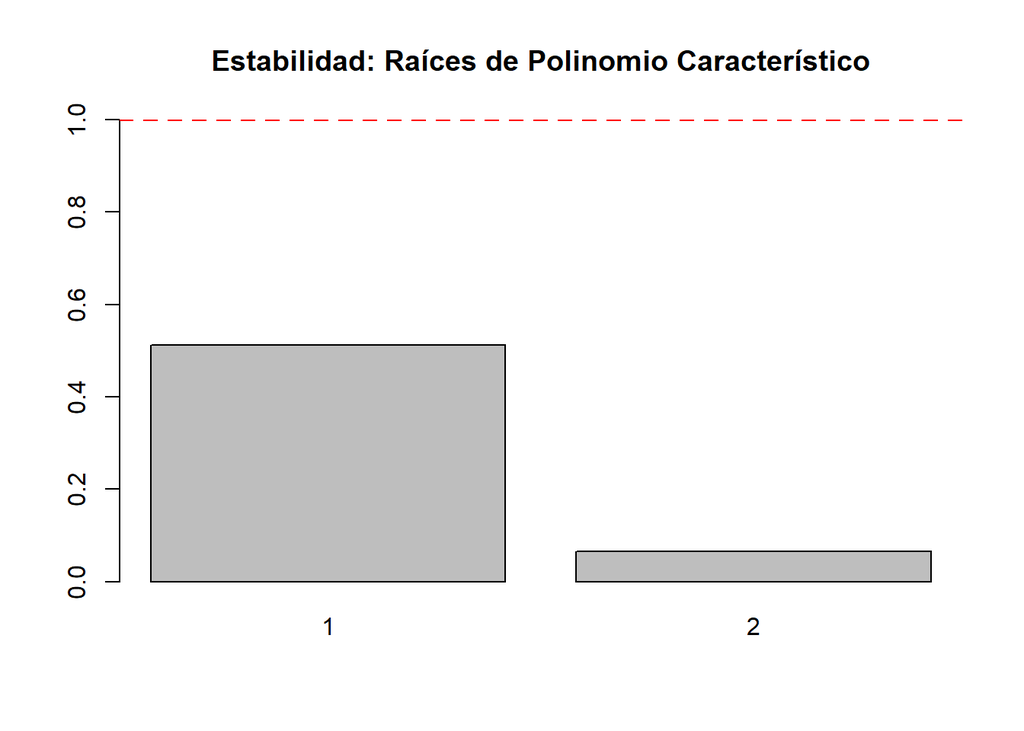

```r
barplot(roots(var1.est), ylim = c(0,1),
        main = "Estabilidad: Raíces de Polinomio Característico",
        names.arg = as.character(1:2))
abline(h = 1, col = "red", lty = 2, lwd = 2)
```

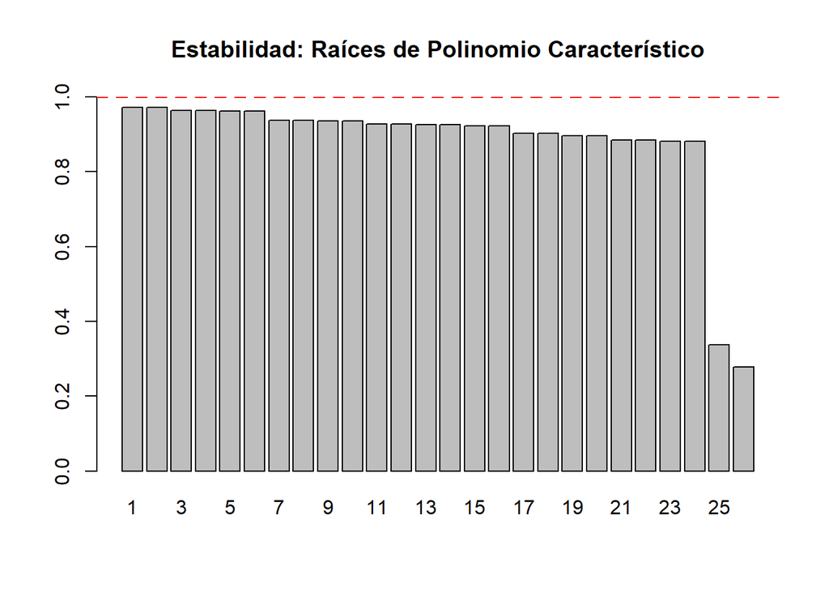

```r
barplot(roots(var13.est), ylim = c(0,1),
        main = "Estabilidad: Raíces de Polinomio Característico",
        names.arg = as.character(1:26))
abline(h = 1, col = "red", lty = 2, lwd = 2)
```

En los dos modelos VAR las raíces son menores que 1, lo que indica estabilidad

## Chequeando los residuales de los VAR

La evaluación de los residuales permitirá determinar cual de los modelos se ajusta mejor

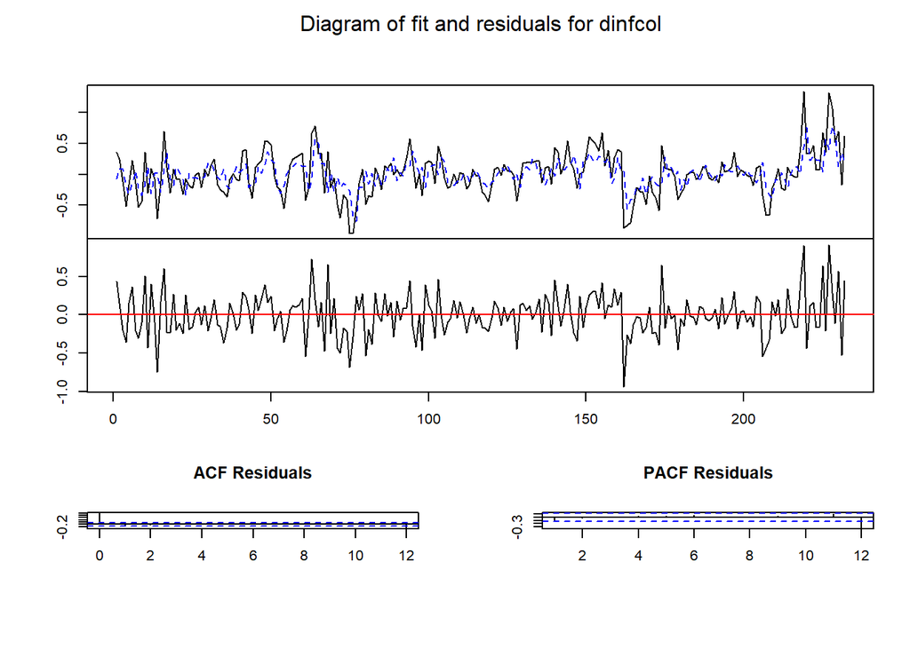

```r
plot(var1.est, names = "dinfcol")
```

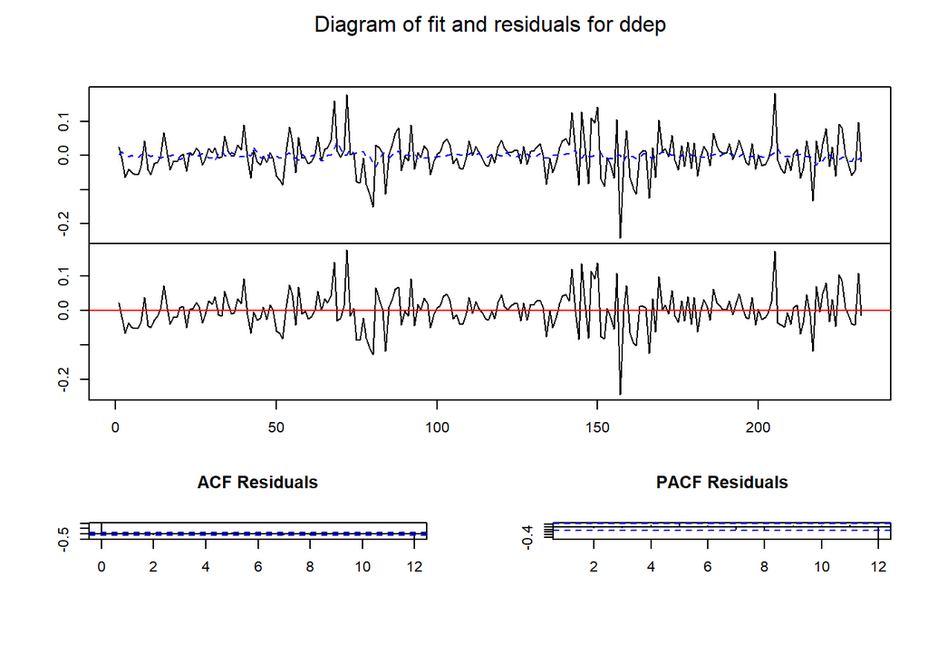

```r
plot(var1.est, names = "ddep")
```

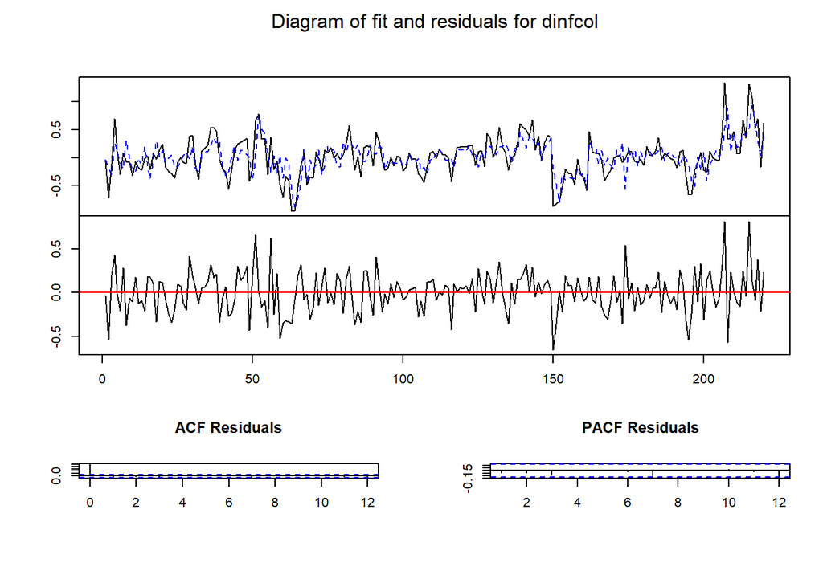

```r
plot(var13.est, names = "dinfcol")
```

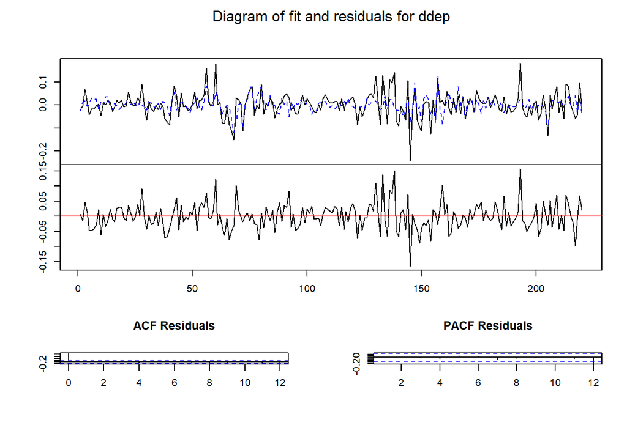

```r
plot(var13.est, names = "ddep")
```

Al parecer el VAR(13) presenta un mejor ajustes. Miremos pruebas formales de autocorrelación, heteroscedasticidad y normalidad

## Autocorrelación

```r
var1.serial1 <- serial.test(var1.est, lags.pt = 20, type = "PT.asymptotic")
var1.serial1
```

```
##
##  Portmanteau Test (asymptotic)
##
## data:  Residuals of VAR object var1.est
## Chi-squared = 162.41, df = 76, p-value = 3.202e-08
```

```r
var13.serial <- serial.test(var13.est, lags.pt = 20, type = "PT.asymptotic")
var13.serial
```

```
##
##  Portmanteau Test (asymptotic)
##
## data:  Residuals of VAR object var13.est
## Chi-squared = 52.846, df = 28, p-value = 0.00306
```

En los dos modelos se rechaza la $H_0$: no autocorrelación, lo cual indica problemas de autocorrelación

## Heteroscedasticidad

```r
var1.hetero <- arch.test(var1.est, lags.multi = 5)
var1.hetero
```

```
##
##  ARCH (multivariate)
##
## data:  Residuals of VAR object var1.est
## Chi-squared = 93.377, df = 45, p-value = 3.087e-05
```

```r
var13.hetero <- arch.test(var13.est, lags.multi = 5)
var13.hetero
```

```
##
##  ARCH (multivariate)
##
## data:  Residuals of VAR object var13.est
## Chi-squared = 62.139, df = 45, p-value = 0.04589
```

Se observa que se rechaza $H_0$: homoscedasticidad, lo cual indica problemas de heteroscedasticidad

## Normalidad

```r
var1.norm <- normality.test(var1.est)
var1.norm
```

```
## $JB
##
##  JB-Test (multivariate)
##
## data:  Residuals of VAR object var1.est
## Chi-squared = 63.779, df = 4, p-value = 4.651e-13
##
##
## $Skewness
##
##  Skewness only (multivariate)
##
## data:  Residuals of VAR object var1.est
## Chi-squared = 0.96046, df = 2, p-value = 0.6186
##
##
## $Kurtosis
##
##  Kurtosis only (multivariate)
##
## data:  Residuals of VAR object var1.est
## Chi-squared = 62.819, df = 2, p-value = 2.287e-14
```

```r
var13.norm <- normality.test(var13.est)
var13.norm
```

```
## $JB
##
##  JB-Test (multivariate)
##
## data:  Residuals of VAR object var13.est
## Chi-squared = 41.83, df = 4, p-value = 1.809e-08
##
##
## $Skewness
##
##  Skewness only (multivariate)
##
## data:  Residuals of VAR object var13.est
## Chi-squared = 8.4586, df = 2, p-value = 0.01456
##
##
## $Kurtosis
##
##  Kurtosis only (multivariate)
##
## data:  Residuals of VAR object var13.est
## Chi-squared = 33.371, df = 2, p-value = 5.67e-08
```

Se observa que los residuales de los modelos no son normales (se rechaza $H_0$: normalidad)

# Test de causalidad de Granger

```r
var1.cause.infcol <- causality(var1.est, cause = "ddep")
var1.cause.infcol
```

```
## $Granger
##
##  Granger causality H0: ddep do not Granger-cause dinfcol
##
## data:  VAR object var1.est
## F-Test = 22.379, df1 = 1, df2 = 456, p-value = 2.99e-06
##
##
## $Instant
##
##  H0: No instantaneous causality between: ddep and dinfcol
##
## data:  VAR object var1.est
## Chi-squared = 1.0761, df = 1, p-value = 0.2996
```

```r
var13.cause.infcol <- causality(var13.est, cause = "ddep")
var13.cause.infcol
```

```
## $Granger
##
##  Granger causality H0: ddep do not Granger-cause dinfcol
##
## data:  VAR object var13.est
## F-Test = 2.8431, df1 = 13, df2 = 384, p-value = 0.0006401
##
##
## $Instant
##
##  H0: No instantaneous causality between: ddep and dinfcol
##
## data:  VAR object var13.est
## Chi-squared = 0.1234, df = 1, p-value = 0.7254
```

El test de Granger muestra que la depreciación causa Granger la inflación

## Predicción

Para la predicción de la inflación para Colombia y la depreciación, se deben asignar valores futuros para la variable exogena inflación de los Estados Unidos y luego diferenciarlos. Se toman los datos de inflación en los Estados Unidos de junio de 2022 a enero de 2023 (se toman 8 meses que al diferenciar nos da 7 meses), lo cual daría para hacer 7 meses de predicción.

```r
infeeuu_f <- as.matrix(data.frame(dinfeeuu = c(8.93298689, 8.413182026, 8.227361014, 8.214853957, 7.762492677,
                                               7.135348085, 6.444940492, 6.347156218)))
dinfeeuu_f <- diff(infeeuu_f,1)
```

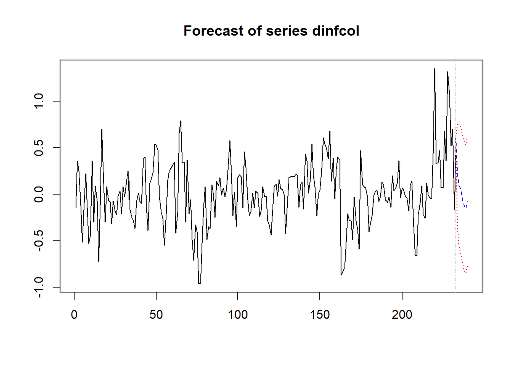

```r
var1.predic <- predict(var1.est, n.ahead = 7, ci = 0.95, dumvar = dinfeeuu_f)
plot(var1.predic, names = "dinfcol")
```

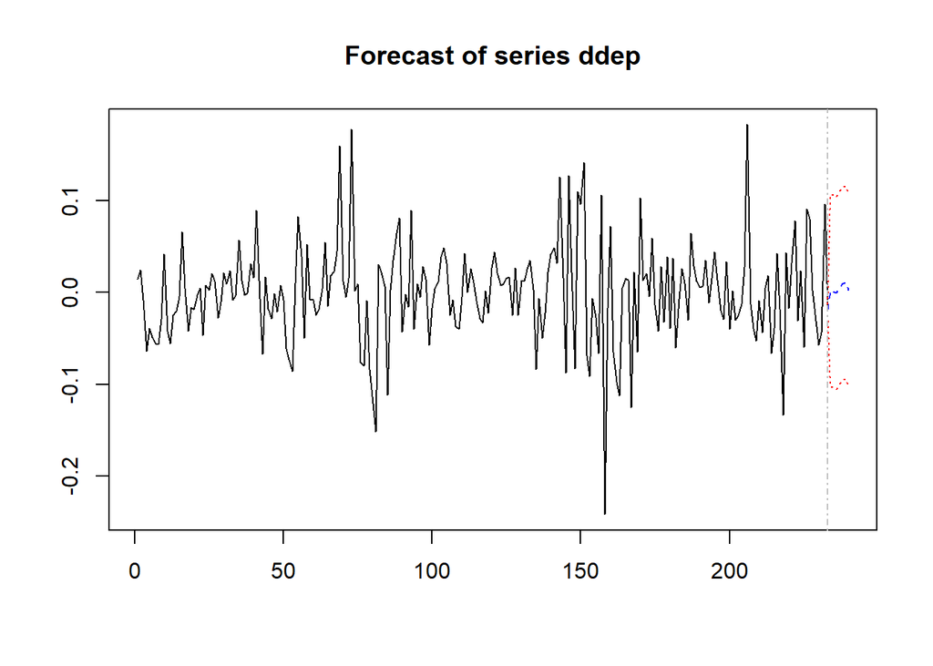

```r
plot(var1.predic, names = "ddep")
```

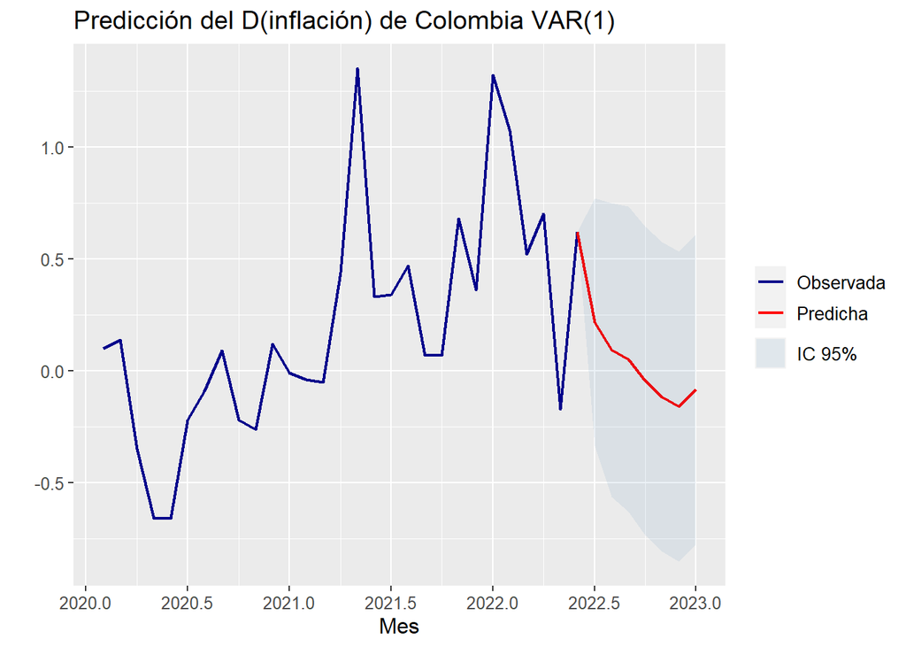

```r
data.predict1 <- data.frame(date = as.yearmon(seq(as.Date("2003-01-01"), as.Date("2023-01-01"), by = "month"), "%m-%Y"),
                            predicho = c(rep(NA, length(data$dinfcol) - 1), data$dinfcol[length(data$dinfcol)],
                                               var1.predic$fcst$dinfcol[1:7,1]),
                            ic_l = c(rep(NA, length(data$dinfcol) - 1), data$dinfcol[length(data$dinfcol)],
                                               var1.predic$fcst$dinfcol[1:7,2]),
                            ic_u = c(rep(NA, length(data$dinfcol) - 1), data$dinfcol[length(data$dinfcol)],
                                               var1.predic$fcst$dinfcol[1:7,3]),
                            actual = c(data$dinfcol, rep(NA, 7)))

ggplot(data.predict1[data.predict1$date>"ene. 2020",]) +
  geom_line(aes(x = date, y = actual, color = "Observada"), size = 0.8) +
  geom_line(aes(x = date, y = predicho, color = "Predicha"), size = 0.8) +
  geom_ribbon(aes(x = date, y = predicho, ymin = ic_l, ymax = ic_u, fill="IC"), alpha = 0.1) +
  theme(legend.text = element_text(size = 10), text = element_text(size=12), legend.spacing.y = unit(-0.3, "cm"), legend.background=element_blank()) +
  guides(shape = guide_legend(order = 2),col = guide_legend(order = 1)) + scale_color_manual(name = "", values = c("Observada" = "darkblue", "Predicha" = "red")) +
  scale_fill_manual(values = c(IC = "steelblue"), labels = c(IC = "IC 95%")) +
  labs(title = "Predicción del D(inflación) de Colombia VAR(1)", x = "Mes", y ="", fill = "") +
  scale_x_continuous(n.breaks = 8)
```

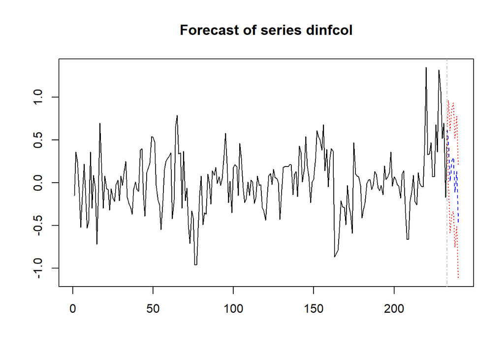

```r
var13.predic <- predict(var13.est, n.ahead = 7, ci = 0.95, dumvar = dinfeeuu_f)
plot(var13.predic, names = "dinfcol")
```

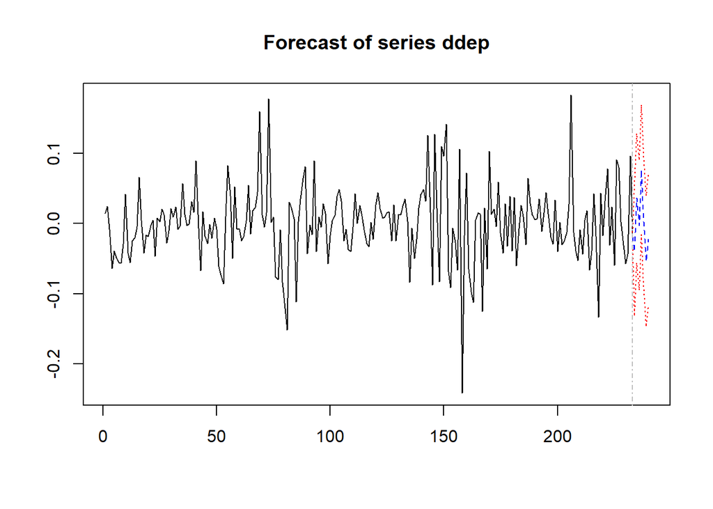

```r
plot(var13.predic, names = "ddep")
```

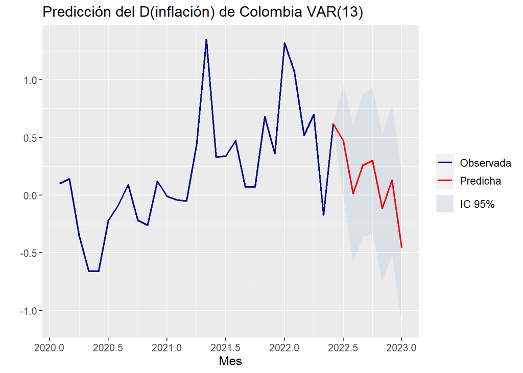

```r
data.predict13 <- data.frame(date = as.yearmon(seq(as.Date("2003-01-01"), as.Date("2023-01-01"), by = "month"), "%m-%Y"),
                            predicho = c(rep(NA, length(data$dinfcol) - 1), data$dinfcol[length(data$dinfcol)],
                                               var13.predic$fcst$dinfcol[1:7,1]),
                            ic_l = c(rep(NA, length(data$dinfcol) - 1), data$dinfcol[length(data$dinfcol)],
                                               var13.predic$fcst$dinfcol[1:7,2]),
                            ic_u = c(rep(NA, length(data$dinfcol) - 1), data$dinfcol[length(data$dinfcol)],
                                               var13.predic$fcst$dinfcol[1:7,3]),
                            actual = c(data$dinfcol, rep(NA, 7)))

ggplot(data.predict13[data.predict13$date>"ene. 2020",]) +
  geom_line(aes(x = date, y = actual, color = "Observada"), size = 0.8) +
  geom_line(aes(x = date, y = predicho, color = "Predicha"), size = 0.8) +
  geom_ribbon(aes(x = date, y = predicho, ymin = ic_l, ymax = ic_u, fill="IC"), alpha = 0.1) +
  theme(legend.text = element_text(size = 10), text = element_text(size=12), legend.spacing.y = unit(-0.3, "cm"), legend.background=element_blank()) +
  guides(shape = guide_legend(order = 2),col = guide_legend(order = 1)) + scale_color_manual(name = "", values = c("Observada" = "darkblue", "Predicha" = "red")) +
  scale_fill_manual(values = c(IC = "steelblue"), labels = c(IC = "IC 95%")) +
  labs(title = "Predicción del D(inflación) de Colombia VAR(13)", x = "Mes", y ="", fill = "") +
  scale_x_continuous(n.breaks = 8)
```

Lo anterior fue la predicción de la serie de inflación diferenciada. Ahora, para hacer la predicción de la serie original se procede como sigue:

$$\Delta x_t = x_t - x_{t-1}$$
$$\Delta x_{t+1} = x_{t+1} - x_{t}$$

Así que, para deducir el valor predicho en niveles seria:
$$x_{t+1} = \Delta x_{t+1} + x_{t}$$

Con los datos predichos de los modelos VAR en diferencias, se puede hacer el cálculo de la prediccion de la variable original de inflación

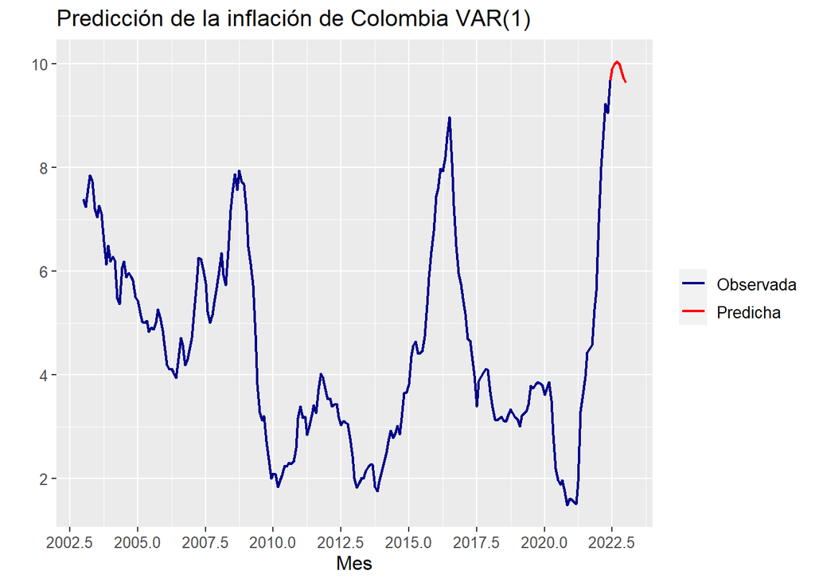

```r
predict1_infcol <- data.frame(infcol_p = NA)

for (i in 1:7) {
predict1_infcol <- data.frame(infcol_p = c(
  data.predict1$predicho[235]+data$infcol[234],
  data.predict1$predicho[236]+predict1_infcol$infcol_p[1],
  data.predict1$predicho[237]+predict1_infcol$infcol_p[2],
  data.predict1$predicho[238]+predict1_infcol$infcol_p[3],
  data.predict1$predicho[239]+predict1_infcol$infcol_p[4],
  data.predict1$predicho[240]+predict1_infcol$infcol_p[5],
  data.predict1$predicho[241]+predict1_infcol$infcol_p[6]))
}

data.predict1infcol <- data.frame(date = as.yearmon(seq(as.Date("2003-01-01"), as.Date("2023-01-01"), by = "month"), "%m-%Y"),
                                  predicho = c(rep(NA, length(data$infcol) - 1), data$infcol[length(data$infcol)], predict1_infcol$infcol_p),
                                  actual = c(data$infcol, rep(NA, 7)))

ggplot(data.predict1infcol) +
  geom_line(aes(x = date, y = actual, color = "Observada"), size = 0.8) +
  geom_line(aes(x = date, y = predicho, color = "Predicha"), size = 0.8) +
  theme(legend.text = element_text(size = 10), text = element_text(size=12), legend.background=element_blank()) +
  guides(shape = guide_legend(order = 2),col = guide_legend(order = 1)) +
  scale_color_manual(name = "", values = c("Observada" = "darkblue", "Predicha" = "red")) +
  labs(title = "Predicción de la inflación de Colombia VAR(1)", x = "Mes", y ="", fill = "") +
  scale_x_continuous(n.breaks = 8) + scale_y_continuous(n.breaks = 6)
```

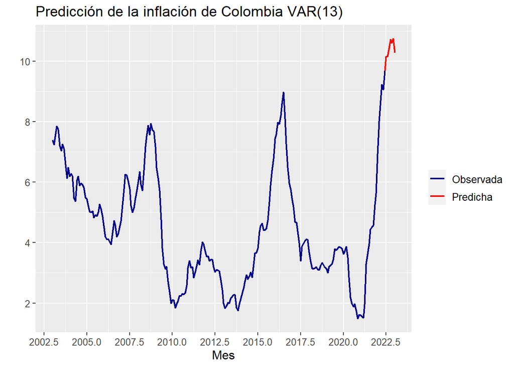

```r
predict13_infcol <- data.frame(infcol_p = NA)

for (i in 1:7) {
predict13_infcol <- data.frame(infcol_p = c(
  data.predict13$predicho[235]+data$infcol[234],
  data.predict13$predicho[236]+predict13_infcol$infcol_p[1],
  data.predict13$predicho[237]+predict13_infcol$infcol_p[2],
  data.predict13$predicho[238]+predict13_infcol$infcol_p[3],
  data.predict13$predicho[239]+predict13_infcol$infcol_p[4],
  data.predict13$predicho[240]+predict13_infcol$infcol_p[5],
  data.predict13$predicho[241]+predict13_infcol$infcol_p[6]))
}

data.predict13infcol <- data.frame(date = as.yearmon(seq(as.Date("2003-01-01"), as.Date("2023-01-01"), by = "month"), "%m-%Y"),
                                  predicho = c(rep(NA, length(data$infcol) - 1), data$infcol[length(data$infcol)], predict13_infcol$infcol_p),
                                  actual = c(data$infcol, rep(NA, 7)))

ggplot(data.predict13infcol) +
  geom_line(aes(x = date, y = actual, color = "Observada"), size = 0.8) +
  geom_line(aes(x = date, y = predicho, color = "Predicha"), size = 0.8) +
  theme(legend.text = element_text(size = 10), text = element_text(size=12), legend.background=element_blank()) +
  guides(shape = guide_legend(order = 2),col = guide_legend(order = 1)) +
  scale_color_manual(name = "", values = c("Observada" = "darkblue", "Predicha" = "red")) +
  labs(title = "Predicción de la inflación de Colombia VAR(13)", x = "Mes", y ="", fill = "") +
  scale_x_continuous(n.breaks = 8) + scale_y_continuous(n.breaks = 6)
```

## Funciones impulso respuesta

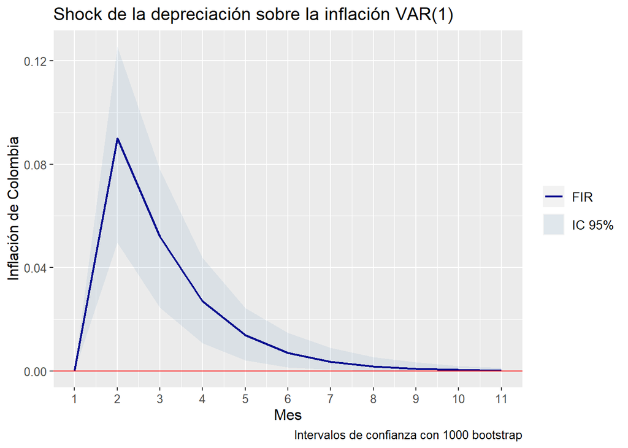

```r
irf1.dinfcol <- irf(var1.est, impulse = "ddep", response = "dinfcol",
                  n.ahead = 10, boot = TRUE, runs = 1000,
                  seed = 0123456789)

data.irf1 <- data.frame(time = seq(1,11,1),
                       irf = irf1.dinfcol$irf$ddep[1:11,1],
                       lower = irf1.dinfcol$Lower$ddep[1:11,1],
                       upper = irf1.dinfcol$Upper$ddep[1:11,1])

ggplot(data.irf1) +
  geom_line(aes(x = time, y = irf, color = "FIR"), size = 0.8) +
  geom_ribbon(aes(x = time, y = irf, ymin = lower, ymax = upper, fill="IC"), alpha = 0.1) +
  theme(legend.text = element_text(size = 10), text = element_text(size=12), legend.spacing.y = unit(-0.3, "cm"), legend.background=element_blank()) +
  guides(shape = guide_legend(order = 2),col = guide_legend(order = 1)) +
  scale_color_manual(name = "", values = c("FIR" = "darkblue")) +
  scale_fill_manual(values = c(IC = "steelblue"), labels = c(IC = "IC 95%")) +
  labs(title = "Shock de la depreciación sobre la inflación VAR(1)", x = "Mes", y ="Inflación de Colombia", fill = "", caption ="Intervalos de confianza con 1000 bootstrap") +
  scale_x_continuous(n.breaks = 11) +
  geom_hline(yintercept=0, color = "red")
```

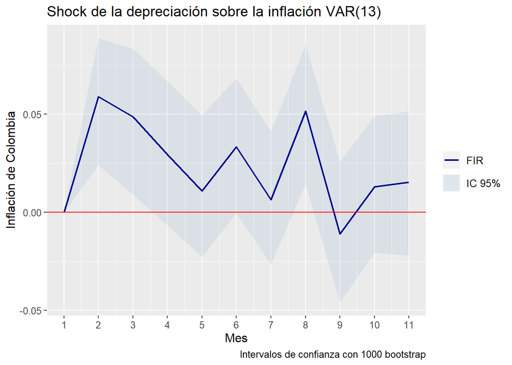

```r
irf13.dinfcol <- irf(var13.est, impulse = "ddep", response = "dinfcol",
                  n.ahead = 10, boot = TRUE, runs = 1000,
                  seed = 0123456789)

data.irf13 <- data.frame(time = seq(1,11,1),
                       irf = irf13.dinfcol$irf$ddep[1:11,1],
                       lower = irf13.dinfcol$Lower$ddep[1:11,1],
                       upper = irf13.dinfcol$Upper$ddep[1:11,1])

ggplot(data.irf13) +
  geom_line(aes(x = time, y = irf, color = "FIR"), size = 0.8) +
  geom_ribbon(aes(x = time, y = irf, ymin = lower, ymax = upper, fill="IC"), alpha = 0.1) +
  theme(legend.text = element_text(size = 10), text = element_text(size=12), legend.spacing.y = unit(-0.3, "cm"), legend.background=element_blank()) +
  guides(shape = guide_legend(order = 2),col = guide_legend(order = 1)) +
  scale_color_manual(name = "", values = c("FIR" = "darkblue")) +
  scale_fill_manual(values = c(IC = "steelblue"), labels = c(IC = "IC 95%")) +
  labs(title = "Shock de la depreciación sobre la inflación VAR(13)", x = "Mes", y ="Inflación de Colombia", fill = "", caption ="Intervalos de confianza con 1000 bootstrap") +
  scale_x_continuous(n.breaks = 11) +
  geom_hline(yintercept=0, color = "red")
```

## Referencias

Posada, CE y Londoño-Sierra, L. (2022). “Retos para la autoridad monetaria en el próximo cuatrenio”. Grupo de Coyuntura Económica. Universidad EAFIT, Medellín-Colombia. https://coyunturaeconomicaeafit.wordpress.com/2022/08/25/retos-para-la-autoridad-monetaria-en-el-proximo-cuatrienio/